# Workshop 5 Worksheet

## Learning outcomes

By the end of the session, you should be familiar with:

- recoding/dichotomising categorical variables in JASP
- interpreting inferential statistics in regression outputs
- understanding and describing the uncertainty around statistical results

## Intro

In this worksheet we will revisit the linear and logistic regression models created in the previous two workshops and we will reassess those results by focusing on the uncertainty around the estimated coefficients and the meaning behind them. You will practice fitting regression models to address your *assignment question of choice*, and in the process we learn some further data transformation procedures in JASP.

## Exercise 6.1: Return to modelling *social trust* at national level as a function of *inequality* and *Region*

### Task 6.1.1: Multiple linear regression

In *Exercise 3 on Worksheet 3* you fit a regression model of *social trust* as a function of *inequality* and *Region* using the `trust_inequality.dta` dataset. In this exercise, refit that multiple linear regression model, but in addition to what you have done in Workshop 4, also request *Confidence intervals (95%)* to be included in the output summary table:

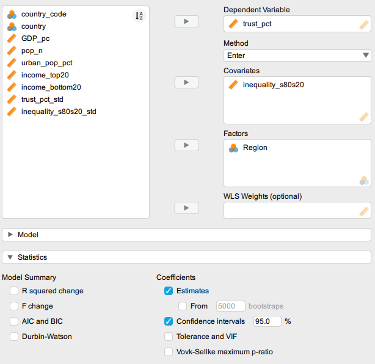

The output *Coefficients* table should look something like this:

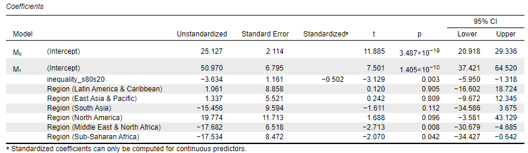

**Questions**

- Using the lecture slides and the assigned readings, interpret the results focusing on the meaning of the “Standard Error”, “95% CI” and “p” columns

### Task 6.1.2: Multiple logistic regression

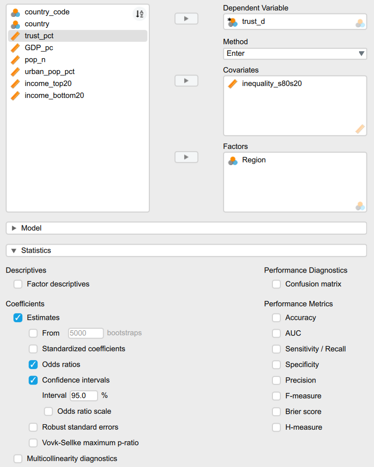

The output *Coefficients* table should look something like this:

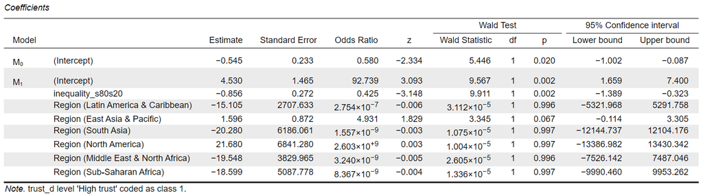

**Questions**

- Using the lecture slides and the assigned readings, interpret the results focusing on the meaning of the “Standard Error”, “95% Confidence Interval” and “p” columns
- Do the coefficients - particularly as viewed through the *confidence intervals* - on the `Region` variable(s) seem plausible? What do you think might be causing the very large “effects” and highly uncertain effects?

*Tip: You may want to check a simple cross-tabulation (contingency table) of `trust_d` by `Region` to develop some intuition in answering the second point above.*

## Exercise 6.2. Recoding categorical variables

In In *Exercise 5.1 - Task 5.1.1 (Worksheet 4)* we dichotomised the `trust_pct` numeric scale-type variable by cutting the scale in two around its mean value. In practical data analysis you will often encounter situations when you will want to recode categorical variables into fewer categories than the original scale. Such a situation may emerge in the course of an *assignment task* in which the variable chosen as *dependent variable* in a planned regression model is multi-categorical (multinomial). There are special statistical models for such dependent variables, however, in this module we are not covering these more advanced methods. Instead, you will want to transform the variables - if logically, conceptually or theoretically possible - into binary/binomial/dichotomous variables (i.e. variables with only two categories).

Such transformations are easy to implement in JASP, and the procedure amounts to manually recoding the values of the categories by giving several categories the same values.

In this exercise, you can use the `data_transformation` dataset available to download from the module website’s Data page to replicate the transformations shown in the two videos below. The downloaded dataset is in `.jasp` format and can be opened directly in the software by double-clicking on the downloaded file.

The procedure for transforming categorical variables is demonstrated in the following YouTube videos:

[video not shown]

## Exercise 6.3. Assignment 1 analysis

You will find a [detailed guide for Assignment 1 on Canvas](https://ncl.instructure.com/courses/58088/pages/assignment-1-detailed-guide?module_item_id=3502431). The guide contains detailed advice on all the steps involved in completing the assignment, including on the structure of the final report. In this exercise, you will focus on the *analysis* component of the assignment which you can then expand or change if your literature review and interpretation of the results necessitate it.

You will perform these analysis steps in JASP, following which you will:

- write down your interpretation of your results in as much detail as possible (either (or both) In JASP notes and your main Word/Text editor document that you are using to write the main text of the report in; it’s a good idea to start saving your notes and interpretations alongside the analysis and outputs directly in JASP to make your work reproducible, then copy it over and adapt it in your main document;
- Select which outputs (descriptive tables, graphs, statistical output tables) you will want to include in the main text of your report and copy them over from JASP into your Word document/text editor. **To copy and paste outputs from JASP, you can click on the small black down-arrows next to the output and select “Copy”, then paste it into your text editor. (Keep in mind that tables will require some manual improvements in Word/text editor to make the content fit the page well).**

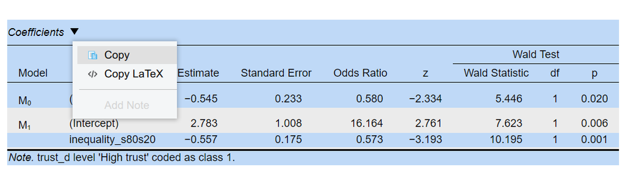

- Make sure to give a caption/title to your graphs and tables in your report.